# ESA Stats Region of Common Profiles (RCP)

Skipton N.C. Woolley$^{1,2*}$, Scott D. Foster$^3$, Nicole Hill$^4$ & Piers K. Dunstan$^2$

$^1$ School of Ecosystem and Forest Sciences, The University of Melbourne, Parkville, Australia, 3010

$^2$ Oceans and Atmospheres CSIRO, Hobart, TAS, Australia, 7000

$^3$ Data61 CSIRO, Hobart, TAS, Australia, 7000

$^4$ University of Tasmania, Hobart, TAS, Australia, 7000

$^*$ skipton.woolley@unimelb.edu.au

06/12/2021

## Setting up R to run ecomix

```r
library(devtools)
install_github("skiptoniam/ecomix@dev")
```

## Regions of Common Profile Models

The Regions of Common Profile (RCP) models are a type of ‘Mixture-of-Experts Models’ and try to describe how homogeneous groups of **sites** vary with the environment. This is done by grouping sites based on the biological content (species observed at each site) and determine how these groups vary across environmental or physical gradients (Foster *et al.* 2013). This approach assumes that assemblages of species at a site exists, and each assemblage can be described by its mean expectation of all species at that site. Within the the RCP model, these indicies are used to represent the data: sites as $i = 1...n$, species as $j = 1...S$ and groups as $k = 1...K$ (we refer to these as RCPs). The model conditional expectation (given site membership) for all species is, $\mathbb{E}(y_{ij}|z_{ik}=1)$. The model can be described as:

$$\begin{equation}
h[\mathbb{E}(y_{ij}|z_{ik})] = \alpha_j + Z_i^\top\tau_j + W_i^\top\gamma_j + \nu_i \tag{2}\label{eq:two}
\end{equation}$$
Where $\alpha_j$ is a species-specific intercept, $Z_j^\top$ is a indicator function used to describe which RCPs the site is in. $\tau_j$ is a $K \times 1$ vector of species parameters containing the step changes for each RCP. $W_i$ is a design matrix which represents covariates that could account for sampling biases in the observation of species at site $i$, $\gamma_j$ are species-specific parameters which describes these biases.

$z_i$ is an unobserved variable and is treated as a latent factor. The model assumes that $z_i$ is the result of a multinomial sampling process with one trial and $k x 1$ probability vector $\pi_i$. The RCP model allows the RCP probability vector $\pi_i$ to vary depending on the observation site’s position in environmental and geographical space. Where $\pi_i=h(X_i)$, and $X_i$ is the design matrix which contains the environmental and spatial covariates to describe site $i$. $h(.)$ is represented by a additive logistic function (Aitchison 1982) whose $k$th component is represented as:

$$\begin{equation}
\pi_{ik}\triangleq h(X_i,k)=
\begin{cases}
\frac{exp(X_i^\top\beta_k)}{1 + \sum_{m=1}^{K-1}\exp{X_i^\top\beta_{k'}}}, & \text{if $1 \leq k \leq K-1$,}\\
1 + \sum_{m=1}^{K-1}\pi_{ik'}, & \text{if $k = K$,}\tag{3}\label{eq:three}
\end{cases}
\end{equation}$$

### Example. Modelling sub-Antarctic demersal fishes abundance with seasonal effects

#### Data and model structure

Here we present an example that uses the Region of Common Profiles (RCP) model to generate an ecoregionalisation for the Kerguelen Plateau in the Sub-Antarctic region (Foster *et al.* 2017). This is an example which comes from a independent random stratified trawl survey to understand the status of the target and bycatch species in the Kerguelen Region. This study looked at fish abundance data from the Autumn 1990, Summer 1992 & Spring 1993.

Load packages and helper functions

```r
library(ecomix)
library(raster)
library(rasterVis)
library(tidyr)
library(ggplot2)
library(reshape2)
library(forcats)
library(dplyr)
source("R/RCP_Helper_Functions.R")
```

Plot up the study area, we can see there are season differences in where they sampled.

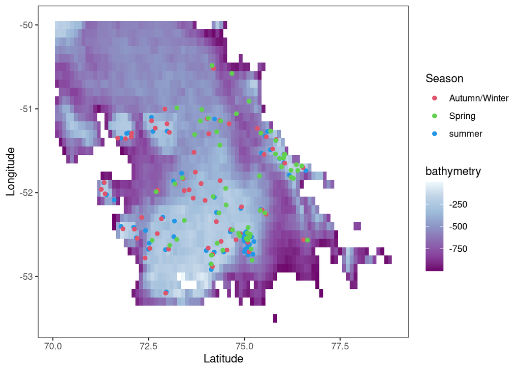

```r
fish<-read.csv("data/SubAntFish_bioenv.csv")
pred_masked<-brick("data/pred_masked")

df.env <- as.data.frame(rasterToPoints(pred_masked[[2]]))
# species <-names(fish)[9:23]
sites <- data.frame(fish[,3:5])
ggplot(sites)+
  geom_raster(data = df.env,aes(x=x,y=y,fill=bathymetry))+
  geom_point(aes(x=Long_MP,Lat_MP,colour=Season))+
  scale_colour_manual(values = c(2,3,4))+
  scale_fill_distiller(palette = "BuPu")+
  theme_bw()+
  theme(panel.grid = element_blank()) +
  xlab("Latitude")+
  ylab("Longitude")
```

We are fitting a relatively simple model here, so let’s have a look at the covariates we will in the model and for spatial prediction.

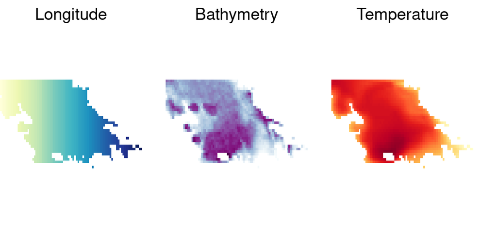

Environmental predictors across Kerguelen Plateau

### Model fitting and evaluation

#### Multiple fits and group selection

We need to set up the RCP formula, which describes the functional form of the model for each RCP. The RCP formula uses the same structure as the Archetype formula in `species_mix`. We also need to setup the species formula, which describes covariates which can control for sampling bias in the data. This uses a standard GLM formula without the response, e.g. `~1+x`.

```r
#create RCP formula
RCP_formula <- as.formula(paste("cbind(",paste(species, collapse=", "),")~",paste(names(rcp_data)[18:23], collapse="+")))
species_formula <- ~ Season
print(RCP_formula)
```

```
## cbind(Bathyraja.eatonii, Bathyraja.murrayi, Champsocephalus.gunnari,
##     Channichthys.rhinoceratus, Dissostichus.eleginoides, Gobionotothen.acuta,
##     Lepidonotothen.mizops, Lepidonotothen.squamifrons, Lycodapus.antarcticus,
##     Macrourus.holotrachys, Melanostigma.gelatinosum, Muraenolepis.sp.,
##     Paradiplospinus.gracilis, Paraliparis.operculosus, Zanclorhynchus.spinifer) ~
##     Long_MP1 + Long_MP2 + log_depth1 + log_depth2 + caisom_floor_temperature1 +
##         caisom_floor_temperature2
```

```r
print(species_formula)
```

```
## ~Season
```

The log-likelihoods in RCP models are quiet complicated and it can be hard to optimise the global maxima, there can be a decent chance of getting stuck in local minima. We use a few strategies to help with this during optimisation.

Firstly, we use the multiples fits approach again, given decent model-based starting values, we add a little random variation and use multiple fits (like in `species_mix`) to converge on the best log-likelihood per group $k$. In this example, we use 10 starts (for speed), but the original work by Nicole used 100 starts per $K$.

The second trick we can use, is to to include penalties in the model, we can think of these as greasing the wheels of model fitting, and can help to smooth the log-likelihood a little.

```r
control <- list(penalty=0.01, penalty.tau=10, penalty.gamma=10, penalty.disp=c(10,sqrt(10)),quiet=TRUE)
nstarts <-10
max.nRCP <- 6
nRCPs_samp <- list()
for( ii in 2:max.nRCP)
  nRCPs_samp[[ii]] <- regional_mix.multifit(rcp_formula = RCP_formula,
                                            species_formula = species_formula,
                                            data = rcp_data,
                                            nRCP=ii,
                                            family = "negative.binomial",
                                            inits="random2",
                                            control=control,
                                            nstart=nstarts)
save(nRCPs_samp,file = "model_results/sub_ant_rcps_multifit_10starts.RData")
```

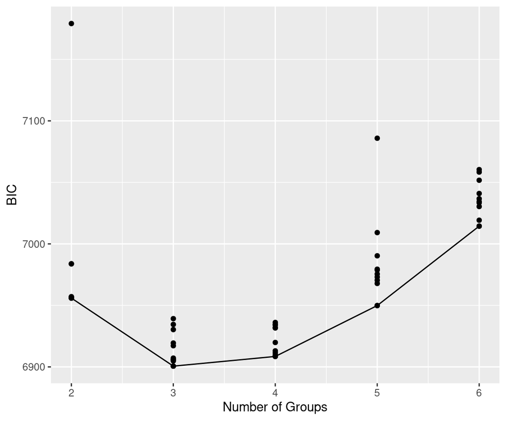

```r
load('model_results/sub_ant_rcps_multifit_10starts.RData')
max.nRCP<-6
grps <- 2:max.nRCP
RCPsamp_BICs <- sapply( nRCPs_samp[-1], function(x) sapply( x, function(y) y$BIC))
RCPsamp_minPosteriorSites <- cbind(181, sapply( nRCPs_samp[-1], function(y) sapply( y, function(x) min( colSums( x$postProbs)))))

RCPsamp_minBICs <- apply( RCPsamp_BICs, 2, min)

df2a <- data.frame(grps=2:max.nRCP,bic=RCPsamp_minBICs)
df2b <- data.frame(grps=rep(2:max.nRCP, each=nrow( RCPsamp_BICs)),bic=as.numeric(RCPsamp_BICs))
gg1 <- ggplot(df2a,aes(x=grps,y=bic))+
      geom_point()+
      geom_line()+
      geom_point(data=df2b,aes(x=grps,y=bic))+
      scale_x_continuous("Number of Groups", labels = as.character(grps), breaks = grps)+
      ylab("BIC")
gg1
```

#### Refitting of ‘best’ model.

Because of the size of the model objects that are returned from `regional_mix.multi` are quiet large. We set the function use the call `titbits=FALSE`, this basically just returns the bare bones of the model. To do some more interesting things, like diagnostics, we need to refit the model using the ‘best fit’, by passing the coefficients as starting values when refitting.

```r
RCPsamp_goodun <- which.min( RCPsamp_BICs[,3])
control <- list( optimise=TRUE, quiet=TRUE)
RCPsamp_fin <- regional_mix(rcp_formula = RCP_formula,
                            species_formula = species_formula,
                            nRCP = 3,
                            data = rcp_data,
                            family = "negative.binomial",
                            inits = unlist(nRCPs_samp[[3]][[RCPsamp_goodun]]$coef),
                            control = control)
saveRDS(RCPsamp_fin,"model_results/best_sub_ant_rcp_mod.rds")
```

#### Diagnostics

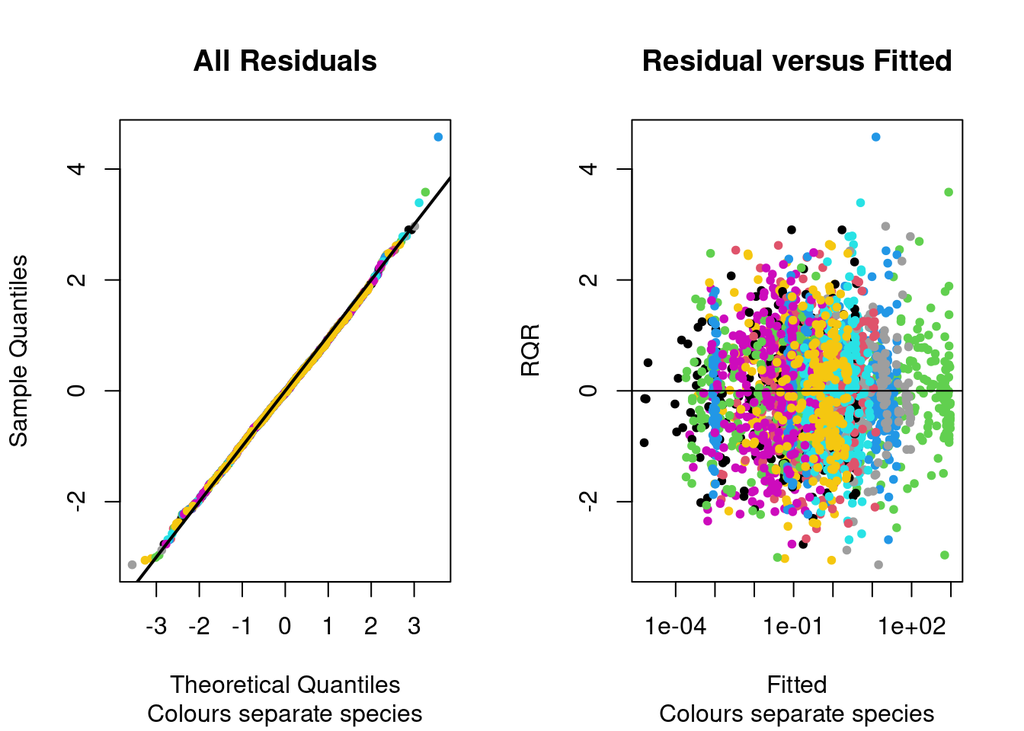

```r
plot(RCPsamp_fin, type="RQR", fitted.scale="log") #looks OK
```

#### Stability of RCPs

Another diagnostic we can look at is the stability of the RCP logls using hold-out-samples. This checks how robust the RCPs are to removing subsets of the data, and also check to see how robust the log-likelihood is to hold-out-tests.

This function is very slow (takes about 10 mins), so I’ve run it previously and saved the results.

```r
stab.results <- stability.regional_mix(RCPsamp_fin,
                                   oosSizeRange=c(1,5,10,20,30,40),
                                   mc.cores=1,
                                   doPlot=FALSE)
save(stab.results, file = "model_results/stability_results_rcp.RData")
```

The plots produced are: * Leave-some-out Cook’s distance (see cooks.distance.regional_mix) against holdout sample size; * The predictive log-likelihood for times sites, against the holdout sample size. In both plots, the values from the original model have been added to the plot.

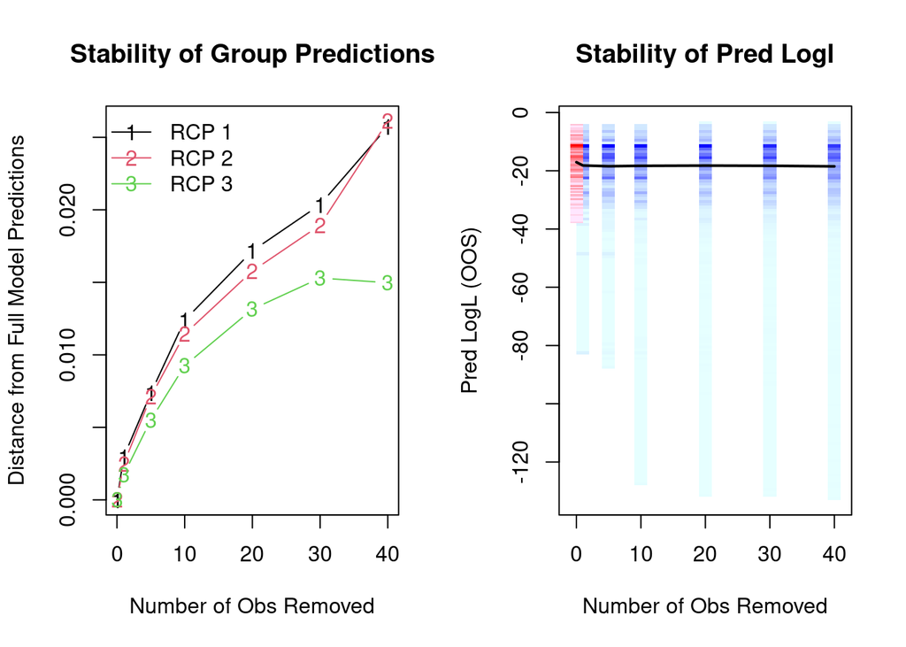

```r
load("model_results/stability_results_rcp.RData")
par(mfrow=c(1,2))
plot(stab.results, minWidth=2, ncuts=111)
```

#### Explore the dispersion parameter as estimated in the Negative Binomial model

Just checking to make sure there are no crazy estimates of dispersion (theta) parameter.

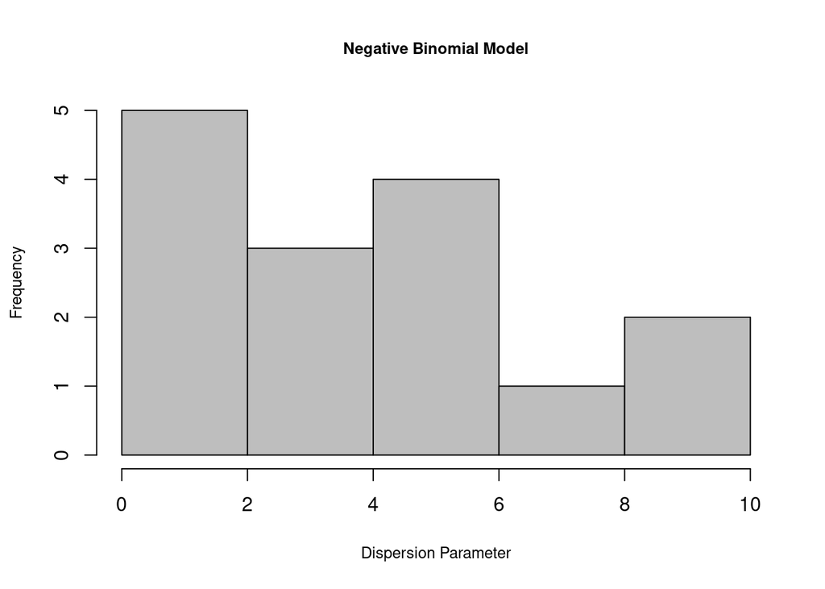

```r
hist(exp(RCPsamp_fin$coefs$disp), xlab="Dispersion Parameter",
     main="Negative Binomial Model", col="grey", cex.main=0.8, cex=0.8, cex.lab=0.8 )
```

#### Bootstrapping for uncertainty

When doing predictions with RCPs we can get an estimate of uncertainty using a “Bayesian Bootstrap”, as discussed in the species_mix example. We can use the bootstrap object in a bunch of plotting and exploratory tools.

```r
rcpsamp_boots <- bootstrap(RCPsamp_fin, type="BayesBoot", nboot=20, mc.cores=1, quiet = TRUE)
save(rcpsamp_boots, file="model_results/rcps_bayes_bootstrap.RData")
```

#### Species Profiles

One thing we are often interested in understanding is the average profile of each species to each RCP. We can think of this as the mean abundance of each species in each RCP. This can be useful for understanding the distribution of species across RCPs, but also as a way of model checking (assuming you have a grab of where species should be) to make sure that nothing weird is happening with the species.

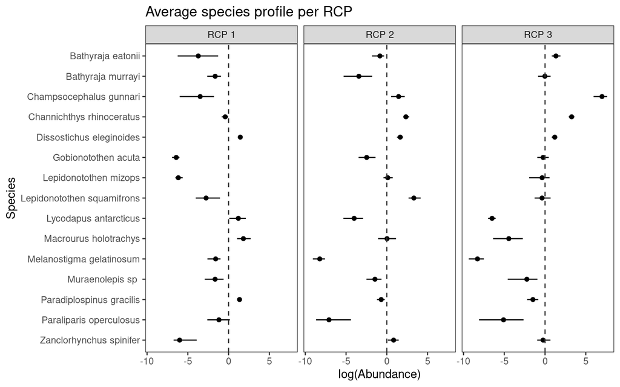

```r
load('model_results/rcps_bayes_bootstrap.RData')
RCP_abund_samp <- regional_mix.species_profile(RCPsamp_fin,rcpsamp_boots,type='link')

df1 <- rbind(cbind(CI="lwr",melt(RCP_abund_samp$overall$lower)),
      cbind(CI="mean",melt(RCP_abund_samp$overall$mean)),
      cbind(CI="upper",melt(RCP_abund_samp$overall$upper)))
colnames(df1)<- c("CI","RCP","Species","Value")
df1$Species <- gsub("[.]"," ",df1$Species)
df <- reshape(df1,idvar=c("Species","RCP"),timevar = "CI",direction = "wide")

rcp_name1 <- c(
  RCP1 = "RCP 1",
  RCP2 = "RCP 2",
  RCP3 = "RCP 3")

gg2 <- ggplot(data =  df) +
       geom_point(aes(x = Value.mean, y = fct_reorder(Species,desc(Species))))+
       geom_linerange(aes(xmin= Value.lwr,xmax=Value.upper, y=   fct_reorder(Species,desc(Species))))+
  facet_wrap(~ RCP, labeller = labeller(RCP = rcp_name1),nrow = 1)+
  ggtitle('Average species profile per RCP')+
  geom_vline(xintercept = 0, col="gray20",lty=2)+
  theme_bw()+
  theme(panel.grid = element_blank()) +
  xlab("log(Abundance)")+
  ylab("Species")
gg2
```

#### The effect of sampling covariates

This shows the estimated sampling coefficients for each species. Here the coefficients are relative to the Autumn sampling. Interval estimates are the 95% confidence intervals obtained from the Bayesian Bootstrapping.

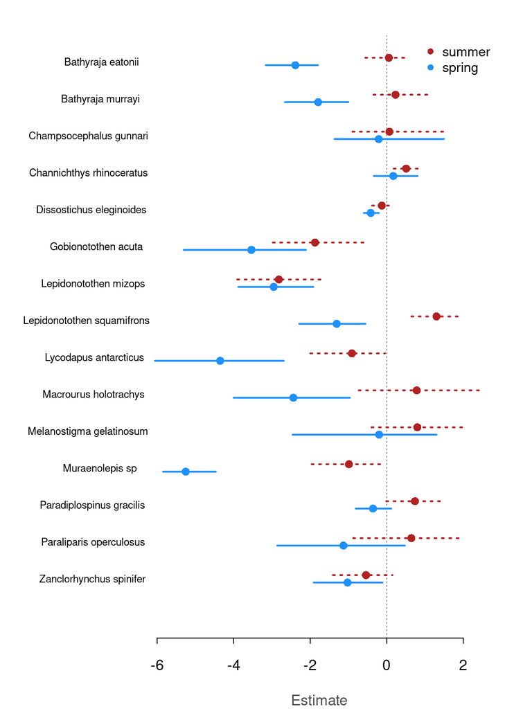

#### Spatial prediction

We can look at the spatial predictions of the RCPs, because RCPs predictions are generated from a multinomial distribution, we always have a probability (sum to 1 across RCPs for each site). This can sometimes be confusing if the data are counts and you are expecting to see a count or density.

Predicted probability of observing each of the RCPs, from the model with sampling effects. We present the point mean predictions and 95% confidence intervals.

```r
RCPsamp_SpPreds <- predict(object=RCPsamp_fin, object2=rcpsamp_boots, newdata=rcp_poly_pred)
```

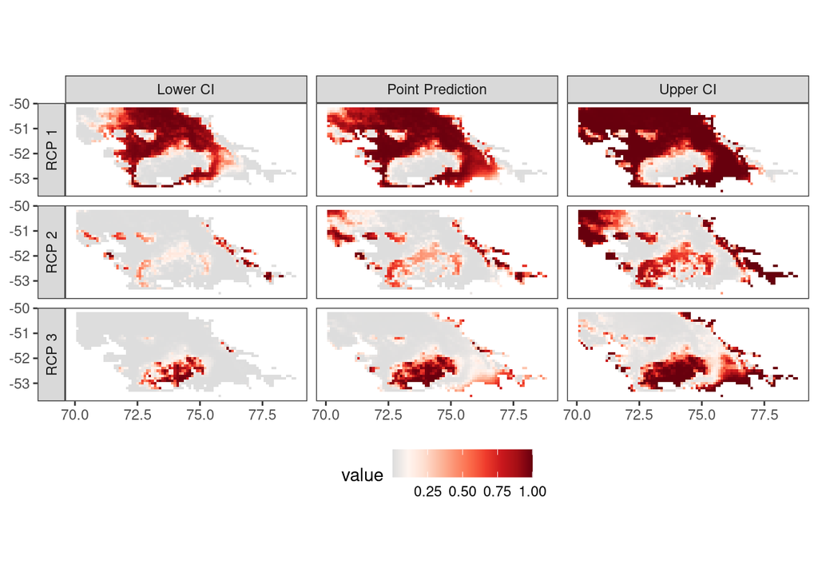

```r
pred.df <- data.frame(x=pred_space_rcp$x,y=pred_space_rcp$y,
                      lwr=RCPsamp_SpPreds$bootCIs[,,1],
                      mean=RCPsamp_SpPreds$bootPred,
                      upper=RCPsamp_SpPreds$bootCIs[,,2])
pred.dfm <- melt(pred.df,id.vars = c("x","y"))
pred.dfm$RCP <- gsub(".*[.]","",pred.dfm$variable)
pred.dfm$CI <- gsub("[.].*","",pred.dfm$variable)
df <- data.frame(pred.dfm)

rcp_name <- c(
  RCP_1 = "RCP 1",
  RCP_2 = "RCP 2",
  RCP_3 = "RCP 3")

ci_name <- c(
  lwr = "Lower CI",
  mean = "Point Prediction",
  upper = "Upper CI")
colour <- c("#dddddd","#fff5f0","#fee0d2","#fcbba1","#fc9272","#fb6a4a","#ef3b2c","#cb181d","#a50f15","#67000d")#,"#000000")
breaks <- c(0, 0.1, 0.2, 0.3, 0.4, 0.5, 0.6, 0.7, 0.8, 0.9, 1)

gg3 <- ggplot() +
  geom_raster(data =  df, aes(x = x, y = y, fill=value)) +
  scale_fill_gradientn(colours = colour, na.value = 'transparent')+
  labs("Probability")+
  facet_grid(RCP ~ CI, labeller = labeller(RCP = rcp_name, CI=ci_name), switch = "y")+
  coord_fixed()+
  theme_bw()+
  theme(axis.title.x = element_blank(),
        axis.title.y = element_blank(),
        # axis.text.x = element_text(angle = 30),
        panel.grid = element_blank(),
        legend.position="bottom",
        legend.box="horizontal") +
  xlab("Longitude")+
  ylab("Latitude")
gg3
```

#### Hard classification

If so desired we can do a hard classification based on the probability of observing each RCPs. We could then consider these ecoregions, based on the species used in this model.

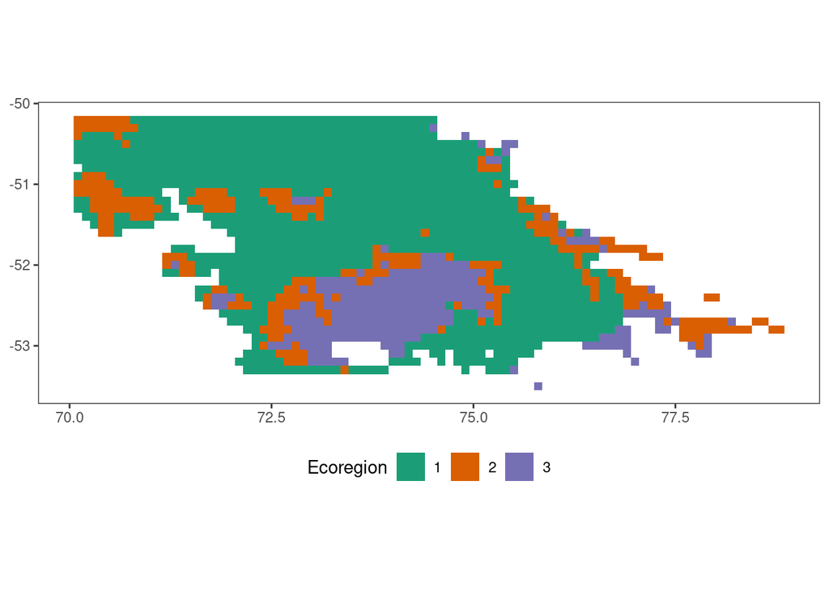

```r
df <- data.frame(x=pred_space_rcp$x,y=pred_space_rcp$y,
                 value=apply(RCPsamp_SpPreds$bootPred,1,which.max))
cols <- RColorBrewer::brewer.pal(3,"Dark2")
gg4 <- ggplot() +
  geom_raster(data =  df, aes(x = x, y = y, fill=factor(value))) +
  scale_fill_brewer(palette = "Dark2", na.value = 'transparent',name="Ecoregion")+
  coord_fixed()+
  theme_bw()+
  theme(axis.title.x = element_blank(),
        axis.title.y = element_blank(),
        # axis.text.x = element_text(angle = 30),
        panel.grid = element_blank(),
        legend.position="bottom",
        legend.box="horizontal") +
  xlab("Longitude")+
  ylab("Latitude")
gg4
```

### References

Aitchison, J. (1982). The statistical analysis of compositional data. *Journal of the Royal Statistical Society. Series B (Methodological)*, 139–177.

Foster, S., Givens, G., Dornan, G., Dunstan, P. & Darnell, R. (2013). Modelling biological regions from multi-species and environmental data. *Environmetrics*, **24**, 489–499.

Foster, S.D., Hill, N.A. & Lyons, M. (2017). Ecological grouping of survey sites when sampling artefacts are present. *Journal of the Royal Statistical Society: Series C (Applied Statistics)*, **66**, 1031–1047.

Hill, N.A., Foster, S.D., Duhamel, G., Welsford, D., Koubbi, P. & Johnson, C.R. (2017). Model-based mapping of assemblages for ecology and conservation management: A case study of demersal fish on the kerguelen plateau. *Diversity and Distributions*, **23**, 1216–1230.

Hill, N., Woolley, S.N., Foster, S., Dunstan, P.K., McKinlay, J., Ovaskainen, O. & Johnson, C. (2020). Determining marine bioregions: A comparison of quantitative approaches. *Methods in Ecology and Evolution*, **11**, 1258–1272.

Lyons, M.B., Foster, S.D. & Keith, D.A. (2017). Simultaneous vegetation classification and mapping at large spatial scales. *Journal of biogeography*, **44**, 2891–2902.

Woolley, S.N., Foster, S.D., Bax, N.J., Currie, J.C., Dunn, D.C., Hansen, C., Hill, N., O’Hara, T.D., Ovaskainen, O., Sayre, R. & others. (2020). Bioregions in marine environments: Combining biological and environmental data for management and scientific understanding. *BioScience*, **70**, 48–59.